# konicek_homework_9

kelli

2025-03-26

# Libraries

```r
library(here)
library(tidyverse)
library(ggeffects)
#install.packages('nlstools')
library(nlstools)
library(MuMIn)
```

## Upload Data

```r
raw_dino <- read_csv(here("week_9", "data","psittacosaurus.csv"))
```

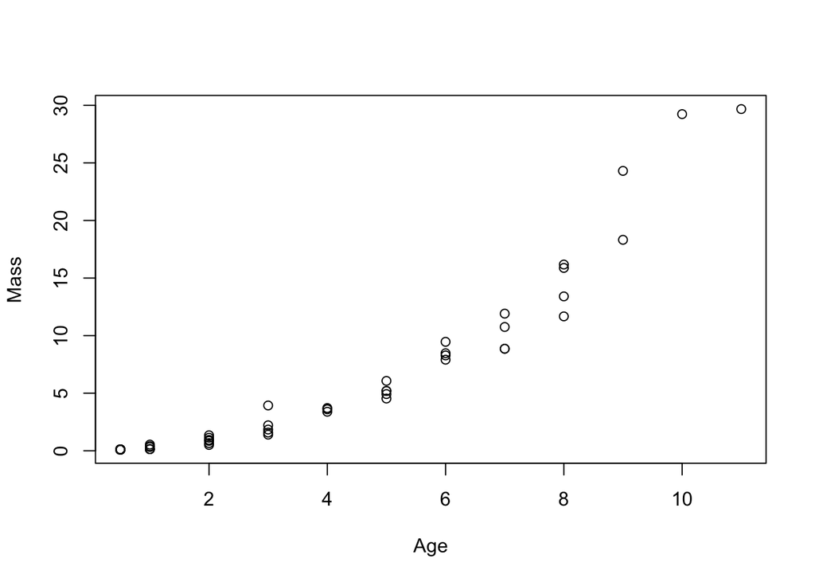

```r
plot(Mass~Age, data=raw_dino)
```

*Fit these three curves to the dataset ‘psittacosaurus.csv’, using nls() as described in lecture. You’ll need to supply start values for the parameters, which may be tricky. If you get error messages when trying to fit the model, use trial-and-error, or try plotting what the curve looks like with different parameter values to come up with reasonable guesses.*

*For each model report the coefficient estimates and confidence intervals, and plot the fitted curves on top of the raw data.*

1. Linear model:

```r
#model
m.linear = nls(Mass ~ a+b*Age, data = raw_dino, start = list(a =1,b=3))

#coefficient estimates and confidence intervals
summary(m.linear)
```

```
##
## Formula: Mass ~ a + b * Age
##
## Parameters:
##   Estimate Std. Error t value Pr(>|t|)
## a -1.86634    0.36948  -5.051 2.82e-06 ***
## b  2.07211    0.09394  22.057  < 2e-16 ***
## ---
## Signif. codes:  0 '***' 0.001 '**' 0.01 '*' 0.05 '.' 0.1 ' ' 1
##
## Residual standard error: 2.432 on 78 degrees of freedom
##
## Number of iterations to convergence: 1
## Achieved convergence tolerance: 1.225e-09
```

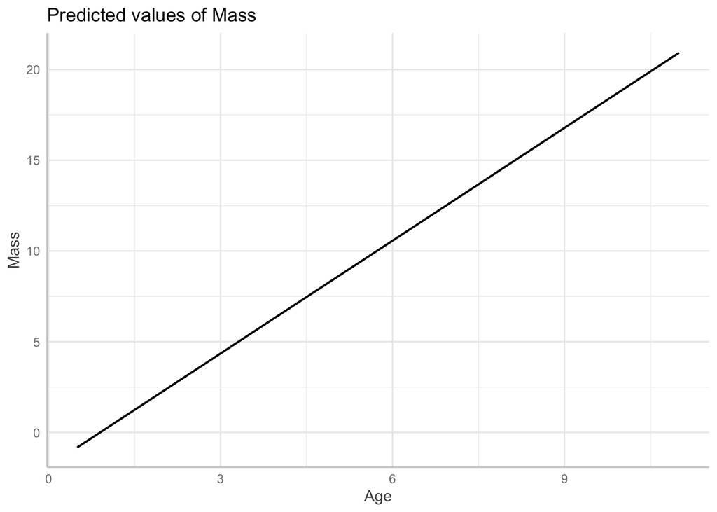

```r
#plot
plot(ggpredict(m.linear,terms = "Age", add.data=TRUE))
```

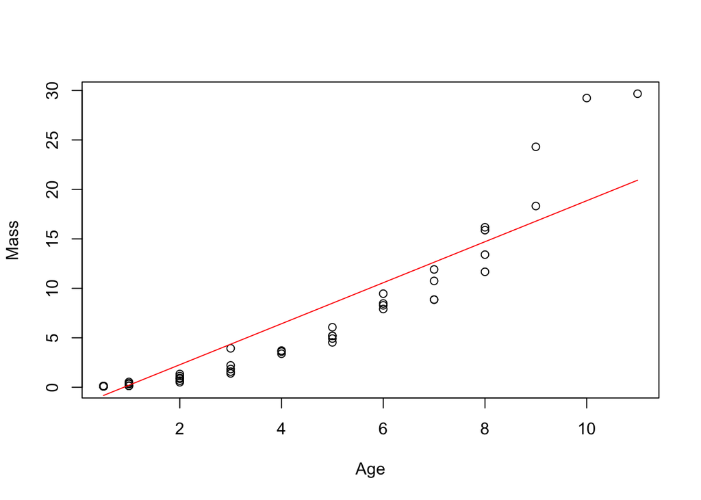

```r
plotfit(m.linear,smooth=TRUE) #from the nlstools vignette- I am struggling with adding my curve to the raw data with base r. The way I am doing it does not seem to have any response to add.data=TRUE like it looks like it should
```

2. Exponential model:

```r
#model
m.exponent = nls(Mass ~ a*exp(r*Age), data = raw_dino, start = list(a = 1, r = 1/28))

#coefficient estimates and confidence intervals
summary(m.exponent)
```

```
##
## Formula: Mass ~ a * exp(r * Age)
##
## Parameters:
##   Estimate Std. Error t value Pr(>|t|)
## a  0.97643    0.09734   10.03  1.1e-15 ***
## r  0.32766    0.01088   30.11  < 2e-16 ***
## ---
## Signif. codes:  0 '***' 0.001 '**' 0.01 '*' 0.05 '.' 0.1 ' ' 1
##
## Residual standard error: 1.519 on 78 degrees of freedom
##
## Number of iterations to convergence: 11
## Achieved convergence tolerance: 6.063e-06
```

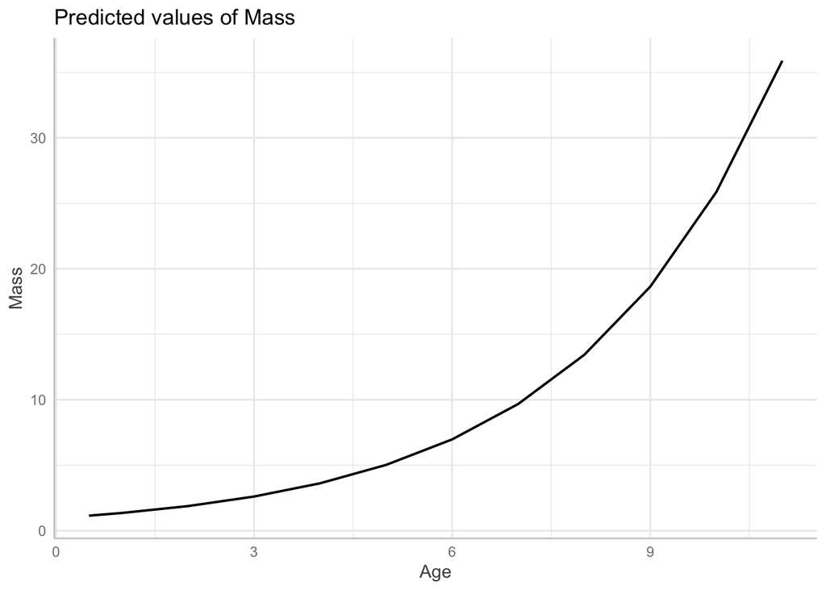

```r
#plot
plot(ggpredict(m.exponent,terms = "Age", add.data=TRUE))
```

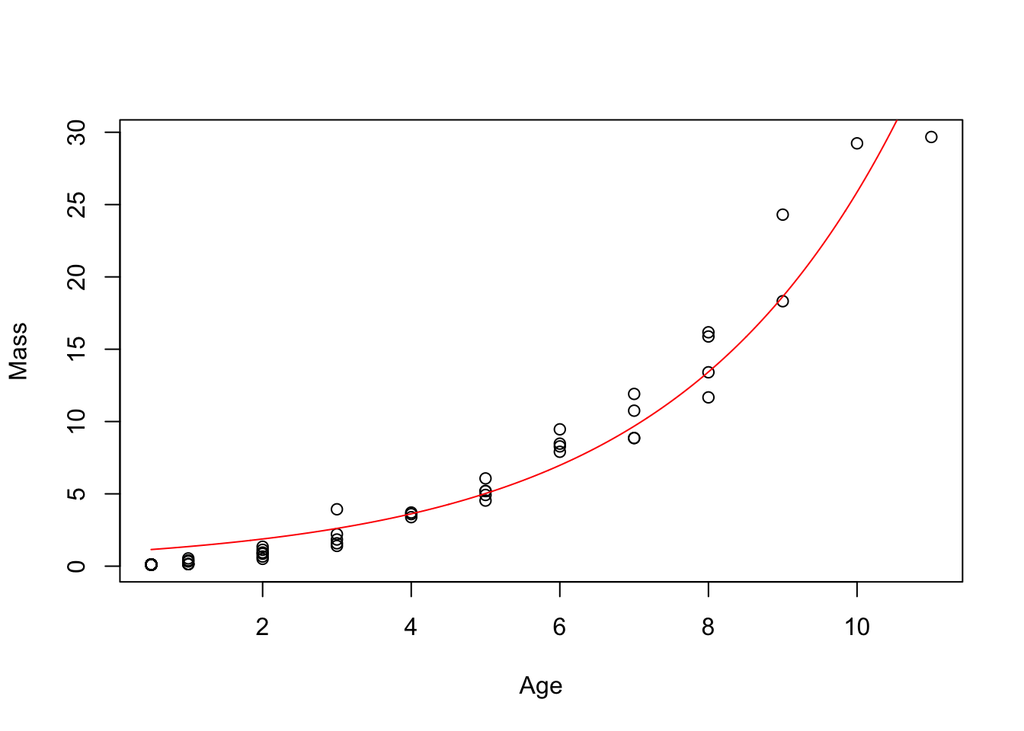

```r
plotfit(m.exponent,smooth=TRUE)
```

3. Logistic model:

```r
#model
m.logistic<- nls(Mass ~ Mmax / (1 + exp(-r * (Age - Age0))), data= raw_dino, start = list(Mmax = max(raw_dino$Mass) , r = 1, Age0 = mean(raw_dino$Age)))


#coefficient estimates and confidence intervals
summary(m.logistic)
```

```
##
## Formula: Mass ~ Mmax/(1 + exp(-r * (Age - Age0)))
##
## Parameters:
##      Estimate Std. Error t value Pr(>|t|)
## Mmax 42.99209    3.67701   11.69   <2e-16 ***
## r     0.51254    0.02854   17.96   <2e-16 ***
## Age0  9.12512    0.35587   25.64   <2e-16 ***
## ---
## Signif. codes:  0 '***' 0.001 '**' 0.01 '*' 0.05 '.' 0.1 ' ' 1
##
## Residual standard error: 1.04 on 77 degrees of freedom
##
## Number of iterations to convergence: 11
## Achieved convergence tolerance: 6.252e-06
```

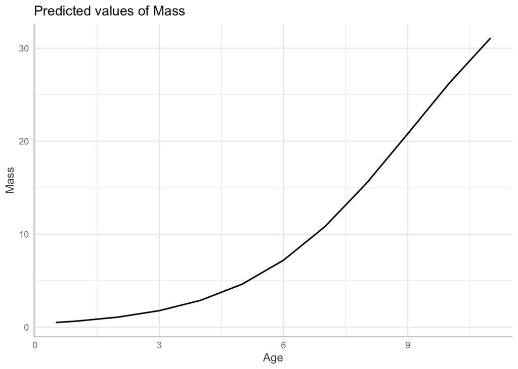

```r
#plot
plot(ggpredict(m.logistic, terms = 'Age',add.data = TRUE))
```

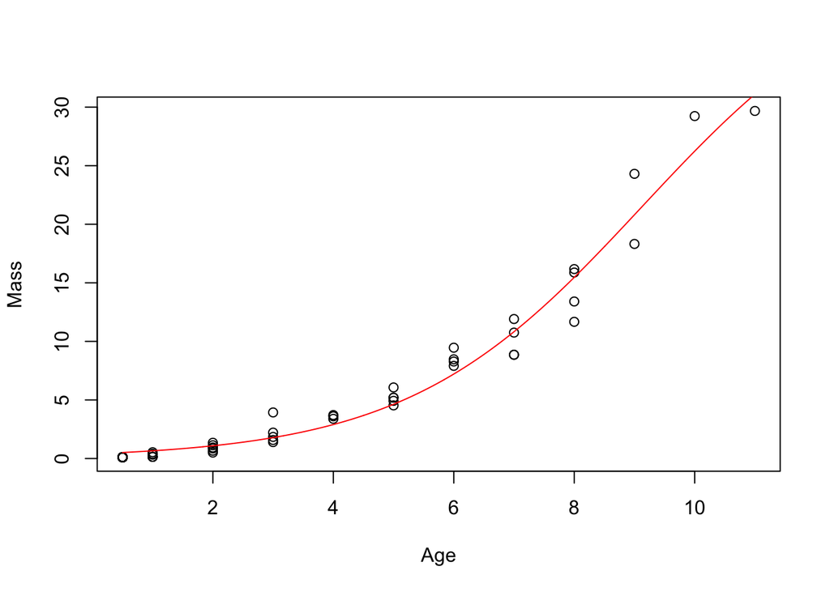

```r
plotfit(m.logistic,smooth=TRUE)
```

Hey! I made the slopes a little different. Hooray.

*Compare the three models using AICc.*

```r
all = list(m.linear,m.exponent,m.logistic)
aic.table = model.sel(all)
aic.table
```

```
## Model selection table
##   (Int)       a Age     b Age:b exp(r*Age) a:exp(r*Age)   Mmx
## 3     +                                                 42.99
## 2     +  0.9764                          +            +
## 1     + -1.8660   + 2.072     +
##   exp(-r*(Age-Ag0)):Mmx                    start df   logLik  AICc  delta
## 3                     + l(mx(r_d$M),1,mn(r_d$A))  4 -115.099 238.7   0.00
## 2                                      l(1,1/28)  3 -145.927 298.2  59.44
## 1                                         l(1,3)  3 -183.611 373.5 134.81
##   weight
## 3      1
## 2      0
## 1      0
## Abbreviations:
##  start: l(1,1/28) = 'list(1,1/28)', l(1,3) = 'list(1,3)',
##         l(mx(r_d$M),1,mn(r_d$A)) = 'list(max(raw_dino$Mass),1,mean(raw_dino$Age))'
## Models ranked by AICc(x)
```

*Which model is the best?*

Well based on my aic.table it looks like the third, logistic model could be the best by far

*What are the ΔAICc values and the Akaike weights for the three models?*

#### Delta AICc:

Linear: 134.81

Exponential: 59.44

Logistic: 0

#### Akaike weights:

Linear:0

Exponential:0

Logistic: 1

*How do you interpret these results in terms of the relative support for the three models?*

It looks like logistic has the only chance of these three models to be the most appropriate, given it’s weight is 1 and the other two are 0. The delta AICc between the logistic and the next most reasonable is almost 60 units, which is a lot. So I think the logistic model has overwhelming support here.

*What is the estimated exponential growth rate (r) for the exponential and logistic models?*

For exponential, r is around ^.33kg/year (right?) For logistic, r is around ^.5kg/year

*What is the confidence interval on this parameter for the two models?*

```r
confint(m.exponent)
```

```
##        2.5%     97.5%
## a 0.8108753 1.1592835
## r 0.3088246 0.3475626
```

```r
confint(m.logistic)
```

```
##            2.5%      97.5%
## Mmax 37.2608577 51.4490025
## r     0.4639475  0.5668192
## Age0  8.5454205  9.8756227
```

so for exponent, the interval is .31-.34 for logistic, the interval is .46-.56. That’s a much larger CI than the exponential model!

*For exponential growth, the doubling time is log(2)/r. How long does it take the dinosaur to double in size, based on the two models?*

```r
log(2)/.33
```

```
## [1] 2.100446
```

```r
log(2)/.51
```

```
## [1] 1.359112
```

*Is there evidence that this dinosaur has a maximum size? If so, what is the estimate for that size, and what is the confidence interval around that estimate?*

logistic model guesses the max size is 43 kg, and the confidence intervals around that are between 37-51 kg.

*How does the estimated maximum size compare to the largest size in the data?*

ALL of those estimated sizes are larger compared to the wee ~30 kg of the max size.

*How much stock do you put in the Mmax estimate, given the data we have?*

I have no flippin’ idea how long this dino guy lives. Since my sigmoidal curve doesn’t asymptote in my observed data, it… I guess, in reality, there could be a really shallow slope on the asymptote? Or maybe the variation in size for these guys means you could potentially have some big guys hanging around? Anyway, I think since I have so little data really I would not hang my hat on this Mmax estimate.

*If this estimate of Mmax is true, about how big does this dinosaur get, relative to a human?*

If I am doing this right, it looks like I probably couldn’t eat a whole one immediately. It is a little smaller than someone who is around 150 lbs or 68 kg. I could probably eat it in like a week if I ate nothing but dinosaur for every meal. I could do it

*Now compare the three models using leave-one-out cross-validation.*

linear

```r
#vector to save the prediction errors
errors = vector()
#the loop: N for total number of observations
for (i in 1:nrow(raw_dino)) {
#make a y-vector that removes observation i from the original y-vector
yuse = raw_dino$Mass[-i]
#make a x-vector that removes observation i from the original x-vector
xuse = raw_dino$Age[-i]
#make a data frame with the new y and x vectors
datause = data.frame(xuse, yuse)
#fit the linear model
mod <- nls(yuse ~ a+b*xuse, data = datause, start = list(a =1,b=3))
#calculate the prediction error for the withheld observation
errors[i] = raw_dino$Mass[i] - predict(mod, newdata = data.frame(xuse = raw_dino$Age[i]))
}
#calculate the root mean squared prediction error
sqrt(mean(errors^2))
```

```
## [1] 2.566121
```

exponent

```r
#vector to save the prediction errors
errors = vector()
#the loop: N for total number of observations
for (i in 1:nrow(raw_dino)) {
#make a y-vector that removes observation i from the original y-vector
yuse = raw_dino$Mass[-i]
#make a x-vector that removes observation i from the original x-vector
xuse = raw_dino$Age[-i]
#make a data frame with the new y and x vectors
datause = data.frame(xuse, yuse)
#fit the exponential model
mod <- nls(yuse ~ a*exp(r*xuse), data = datause, start = list(a = 1, r = 1/28))
#calculate the prediction error for the withheld observation
errors[i] = raw_dino$Mass[i] - predict(mod, newdata = data.frame(xuse = raw_dino$Age[i]))
}
#calculate the root mean squared prediction error
sqrt(mean(errors^2))
```

```
## [1] 2.204835
```

logistic

```r
#vector to save the prediction errors
errors = vector()
#the loop: N for total number of observations
for (i in 1:nrow(raw_dino)) {
#make a y-vector that removes observation i from the original y-vector
yuse = raw_dino$Mass[-i]
#make a x-vector that removes observation i from the original x-vector
xuse = raw_dino$Age[-i]
#make a data frame with the new y and x vectors
datause = data.frame(xuse, yuse)
#fit the logistic model
mod <- nls(yuse ~ Mmax / (1 + exp(-r * (xuse - Age0))), data= datause, start = list(Mmax = max(yuse) , r = 1, Age0 = mean(xuse)))
#calculate the prediction error for the withheld observation
errors[i] = raw_dino$Mass[i] - predict(mod, newdata = data.frame(xuse = raw_dino$Age[i]))
}
#calculate the root mean squared prediction error
sqrt(mean(errors^2))
```

```
## [1] 1.325598
```

*Which model is the best at predicting the data, in terms of LOOCV?*

We are looking for the lowest L00CV RMSE, so that will still be the logistic model at 1.3 (compare to linear at 2.6 and exponential at 2.2)

*What is the typical difference between the predicted values and the observed values for the best model?*

the typical difference is about 1.3 between predicted and observed values.

*Does cross-validation yield the same ranking of models as AICc?*

It did yes.